# E-cig craving project

Haiwen Lei & Xiaohan Zhang

### Executive Summary

E-cigarette, defined by National Cancer Institute, is a device that looks like a cigarette, cigar, or pen but doesn’t contain tobacco. Even though e-cigarette has been proven effective for short-term smoke cessation (Dockrell et al., 2013), it perpetuates nicotine addiction more than other Nicotine Replacement Therapy. More importantly, while the identified common correlate of e-cigarette use was a history of cigarette smoking, a notable proportion of people who never smoked cigarettes had ever-used e-cigarettes (Carroll & Wu, 2014). Due to the perpetuation of nicotine and the potential inducement of cigarette use, it is essential to raise awareness and possibly conduct interventions.

As a result, we are motivated to build a predictive model to predict e-cigarette craving based on the responses to the PATH Study so that those who are interested in awareness promotion and intervention can be more informed. Also, a predictive model gives more leverage to those who want to promote awareness and intervene.

Dataset we used

Population Assessment of Tobacco and Health (PATH) Study is a longitudinal study that captures the respondents’ demographic information, tobacco use behavior, attitudes, and beliefs, as well as related health outcomes. We conducted our model building focusing on the first wave.

Method

First and foremost, we picked 50 variables out of nearly 2000 based on prior knowledge. Since the response rate of our target question, i.e. rate your e-cigarette craving, is extremely low, we decided to remove those who did not answer the target question. Then, KNN data imputation was used to deal with the missing values for other variables so that we can include as many respondents as possible. After filling our dataset with imputed values, we conducted Brouta (a variant for random forest) and machine learning feature selection because we contemplated that 50 variables are still too much for the predictive model. Results from both feature selections are bound together. Using variables selected by feature selection, we build our random forest as well as lasso predictive model. Lastly, RMSE, precision, and accuracy were used to evaluate the lasso and random forest predictive model.

Results

The RMSE of the lasso model is 0.874 while the RMSE of the random forest is 0.886. The accuracy of the random forest is 0.67 while the precision is 0.41. Sensitivity/recall is 0.28. All the results above demonstrate that we generated a model with medium predictive power. Reasons why the model is not perfect are discussed in the limitation section.

Limitation

The predictive model could have performed better if the response rate was higher. A significant non-response rate could jeopardize the model not only because of the missing value bias but also due to the fact that imputation has to be used to make up for the non-response rate. Furthermore, the predictive model could have been better if the process of manually picking the variables was conducted by someone with even more prior knowledge than us. It was possible to miss the variables that were more crucial.

### load the data set

```r
load("D:/DATA SCIENCE PROJECT/E-cig-craving-Project/data/36498-1001-Data.rda")
load("D:/DATA SCIENCE PROJECT/E-cig-craving-Project/data/36498-1002-Data.rda")
load("D:/DATA SCIENCE PROJECT/E-cig-craving-Project/data/36498-2001-Data.rda")
load("D:/DATA SCIENCE PROJECT/E-cig-craving-Project/data/36498-3001-Data.rda")
```

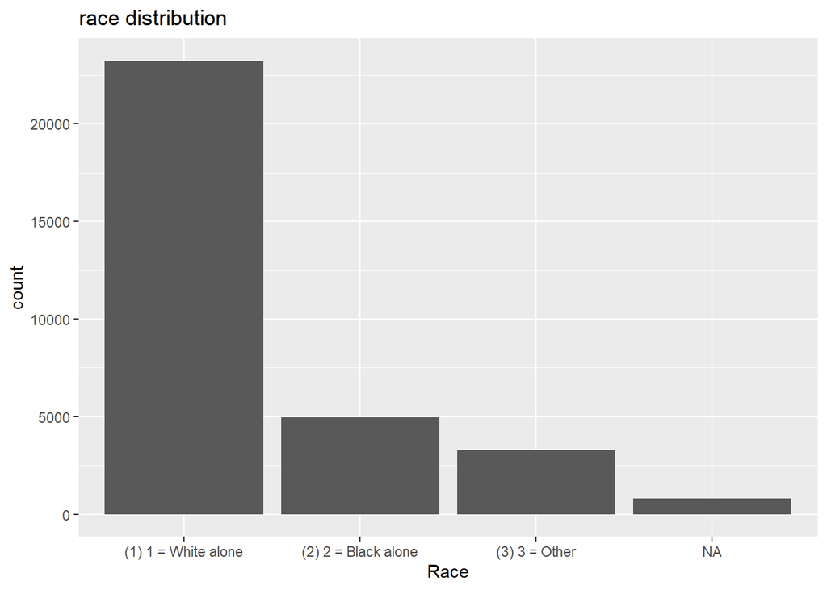

```r
library(tidyverse)
library(ggplot2)
wave1_adult <- da36498.1001
wave1_youth_parent <- da36498.1002


#select variables and data cleaning, the variables are chosen based on the group's knowledge of the subject.
#We looked into the code book and questionnaire for the vairable selection.

chosen_variable_wave1<- wave1_adult %>%
  select(
         R01_AC1002, ##Have you ever smoked a cigarette, even one or two puffs?
         R01_AC1003, ##Do you now smoke cigarettes . . .
         R01_AC1004, ##In the past 30 days, have you smoked a cigarette, even one or two puffs?
         R01_AC9050, ##How harmful do you think cigarettes are to health?
         R01_AE1001, ## Have you ever seen or heard of an electronic cigarette or e-cigarette before this study?
         R01_AE1002, ##Have you ever used an e-cigarette, such as NJOY, Blu, or Smoking Everywhere, even one or two times?
         R01_AE1003, ##Do you now use e-cigarettes . . .
         R01_AE1004, ##In the past 30 days, have you used an e-cigarette, even one or two times?
         R01_AE1022, ##On how many of the past 30 days did you use [e-cigarette / e-cigarette cartridges]?
         R01_AE1008, ##When you first started using e-cigarettes, did you use cartridges or disposable e-cigarettes flavored to taste like menthol, mint, clove, spice, candy, fruit, chocolate, alcohol (such as wine or cognac), or other sweets?
         R01_AE1090, ##Do you own an e-cigarette?
         R01_AE1099, ##Is using e-cigarettes less harmful, about the same, or more harmful than smoking cigarettes?
         R01_AE1100, ##Have you ever used e-cigarettes fairly regularly?
         R01R_A_RACECAT3_IMP, ##Race category
         R01R_A_BMI, ## BMI
         R01R_A_SEXORIENT2,## Sexual Orientation
         R01R_A_AC1006, ##Age range when first smoked part or all of a cigarette
         R01R_A_AE1006, ##Age range when first time used an e-cigarette, even one or two times
         R01R_A_AE1007, ##Age range when first started using e-cigarettes fairly regularly
         R01R_A_AE1020, ## Age range when first started using e-cigarettes every day
         R01R_A_AM0018, ## Highest grade or level of school completed
         R01R_A_AM0030, ## Total household income in the past 12 months
         R01_AN0015, ## Has strong cravings to use / smoke [tobacco products / specific product]
         R01_AN0025, ##Please rate your level of agreement for each statement using the following scale: 1= not true of me at all to 5=extremely true of me.  The following statements are about the use of tobacco and nicotine in general.  I frequently crave [ND FILL2].
         R01_AN0025E, ##Please rate your level of agreement for each statement using the following scale: 1= not true of me at all to 5=extremely true of me.  I frequently crave e-cigarettes.
         R01_AN0215, ## Thinking back to [the time you tried to quit / the last time you tried to quit / when you quit] in the past 12 months, did you use any of the following to help you: counseling, a telephone help line or quit line, books, pamphlets, videos, a quit tobacco clinic, class, or support group, or an internet or web-based program?
         R01_AN0215E, ## Thinking back to [the time you tried to quit / the last time you tried to quit / when you quit] using e-cigarettes in the past 12 months, did you use any of the following to help you: counseling, a telephone help line or quit line, books, pamphlets, videos, a quit tobacco clinic, class, or support group, or an internet or web-based program?
         R01_AN0250, ## To what extent, if at all, do you believe nicotine to be the main substance in tobacco that makes people want to use tobacco products?
         R01_AR0110, ## In the past 30 days, how often, if at all, have you noticed the health warnings on packages of e-cigarettes?
         R01_AR0142, ## In the past 12 months, how often have you thought about the chemicals contained in tobacco products?
         R01_AX0005, ## How would you describe your overall opinion of using tobacco?
         R01_AX0090, ##In general, how would you rate your physical health?
         R01_AX0091, ##In general, how would you rate your mental health, which includes stress, depression, and problems with emotions?
         R01_AX0004,## In the past 30 days, how often did you think about the harm your tobacco use might be doing to you?
         R01_AX0064_01, ## Work setting: Indoors Is your main work area indoors, outdoors, or in a vehicle? Choose all that apply
         R01_AX0064_02, ## Work setting: Outdoors Is your main work area indoors, outdoors, or in a vehicle? Choose all that apply
         R01_AX0064_03, ## Work setting: Vehicle Is your main work area indoors, outdoors, or in a vehicle? Choose all that apply
         R01_AX0065, ## How recently someone smoked around you while at work
         R01_AR0144, ## Lived with a regular smoker who smoked inside your home during childhood
         R01_AX0104,## Extent to which using / past use of tobacco products damaged your health
         R01_AX0105, ## Extent to which you are worried that using / your past use of tobacco products will damage your health in the future
         R01R_A_RACECAT3,## Race category
         R01R_A_CUR_ESTD_CIGS, ## Has ever smoked a cigarette, has smoked more than 100 cigarettes in lifetime, and currently smokes every day or some days.
         R01R_A_EDY_CIGS, ## Has ever used an cigarette, has used fairly regularly, and uses every day.
         R01R_A_SDY_CIGS, ## Has ever used an cigarette, has used fairly regularly, and uses some days
         R01R_A_P30D_CIGS, ## Has ever used an cigarette and has used at least once in the past 30 days
         R01R_A_CUR_ESTD_ECIG, ## Has ever used an e-cigarette, has used fairly regularly, and uses every day or some days.
         R01R_A_EDY_ECIG, ## Has ever used an e-cigarette, has used fairly regularly, and uses every day.
         R01R_A_SDY_ECIG, ## Has ever used an e-cigarette, has used fairly regularly, and uses some days
         R01R_A_P30D_ECIG, ## Has ever used an e-cigarette and has used at least once in the past 30 days
         R01R_A_AGECAT7_IMP, ## Imputed age range,
         )




######### Exploratory data analysis via data visualization



## race and e-cig smoking
df1 <- chosen_variable_wave1 %>%
  mutate(R01_AN0025E = case_when(
    R01_AN0025E == "(1) 1 = Not true of me at all" ~ 1,
    R01_AN0025E == "(2) 2 = 2 on a scale of 1 to 5" ~ 2,
    R01_AN0025E == "(3) 3 = 3 on a scale of 1 to 5" ~ 3,
    R01_AN0025E == "(4) 4 = 4 on a scale of 1 to 5" ~ 4,
    R01_AN0025E == "(5) 5 = Extremely true of me" ~5
  ))%>%
   mutate(R01R_A_CUR_ESTD_ECIG = case_when(
    R01R_A_CUR_ESTD_ECIG == "(1) 1 = Yes" ~ 1,
    R01R_A_CUR_ESTD_ECIG == "(2) 2 = No" ~ 0
  ))%>%
  mutate(R01R_A_EDY_ECIG = case_when(
    R01R_A_EDY_ECIG == "(1) 1 = Yes" ~ 1,
    R01R_A_EDY_ECIG == "(2) 2 = No" ~ 0
  ))%>%
  mutate(R01R_A_SDY_ECIG = case_when(
    R01R_A_SDY_ECIG == "(1) 1 = Yes" ~ 1,
    R01R_A_SDY_ECIG == "(2) 2 = No" ~ 0
  ))%>%
  mutate(R01R_A_P30D_ECIG = case_when(
    R01R_A_P30D_ECIG == "(1) 1 = Yes" ~ 1,
    R01R_A_P30D_ECIG == "(2) 2 = No" ~ 0
  )) %>%
   mutate(R01R_A_CUR_ESTD_CIGS = if_else(R01R_A_CUR_ESTD_CIGS == "(1) 1 = Yes", 1,0 )) %>%
  mutate(R01R_A_EDY_CIGS = if_else(R01R_A_EDY_CIGS == "(1) 1 = Yes", 1,0 )) %>%
  mutate(R01R_A_SDY_CIGS = if_else(R01R_A_SDY_CIGS == "(1) 1 = Yes", 1,0 )) %>%
  mutate(R01R_A_P30D_CIGS = if_else(R01R_A_P30D_CIGS == "(1) 1 = Yes", 1,0 ))%>%
  rename(ecig_craving = R01_AN0025E) %>%
  rename(Race = R01R_A_RACECAT3) %>%
  rename(current_established_ecig_user = R01R_A_CUR_ESTD_ECIG) %>%
  rename(current_everyday_ecig_user = R01R_A_EDY_ECIG) %>%
  rename(current_someday_ecig_user = R01R_A_SDY_ECIG) %>%
  rename(current_past30day_ecig_user = R01R_A_P30D_ECIG)%>%
  rename(current_established_cig_user = R01R_A_CUR_ESTD_CIGS) %>%
  rename(current_everyday_cig_user = R01R_A_EDY_CIGS) %>%
  rename(current_someday_cig_user = R01R_A_SDY_CIGS) %>%
  rename(current_past30day_cig_user = R01R_A_P30D_CIGS)%>%
  rename(smooking_cigarettes = R01_AC1003)





#race distribution
df1 %>%
  ggplot()+
  geom_bar(aes(x = Race))+
  labs(title = "race distribution")
```

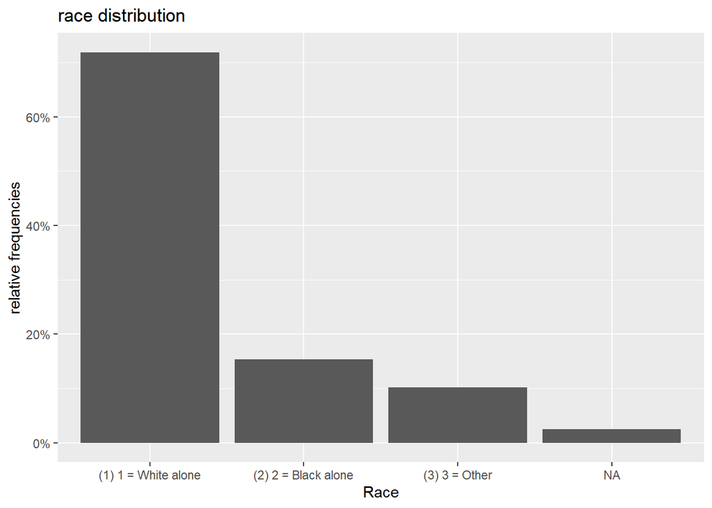

```r
df1 %>%
  ggplot(aes(Race)) +
  geom_bar(aes(y = (..count..)/sum(..count..)))+
  scale_y_continuous(labels=scales::percent) +
          ylab("relative frequencies")+
  labs(title = "race distribution")
```

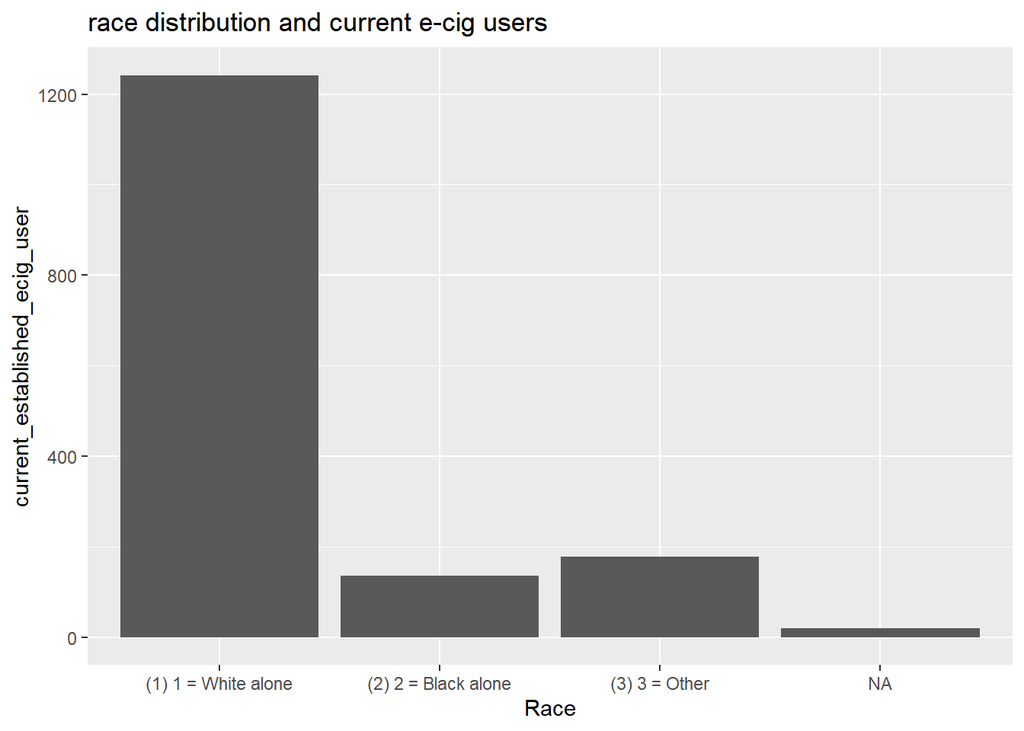

```r
df1 %>%
  ggplot()+
  geom_col(aes(x = Race, y = current_established_ecig_user))+
  labs(title = "race distribution and current e-cig users")
```

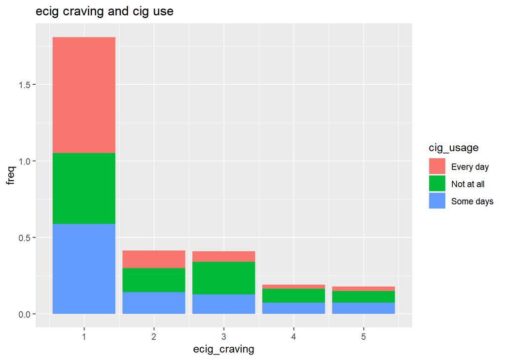

```r
## ecig craving and cig use
df_graph3 <- df1%>%
  select(ecig_craving, smooking_cigarettes)%>%
  mutate(cig_usage = case_when(
    smooking_cigarettes == "(1) 1 = Every day"~ "Every day",
    smooking_cigarettes == "(2) 2 = Some days" ~ "Some days",
    smooking_cigarettes == "(3) 3 = Not at all" ~ "Not at all"
    ))%>%
  na.omit()%>%
  group_by(cig_usage, ecig_craving)%>%
  summarise(n = n())%>%
  mutate(freq = n / sum(n))%>%
  ungroup()
df_graph3%>%
  ggplot()+
  geom_col(aes(x = ecig_craving, y = freq, fill = cig_usage ))+
  labs(title = "ecig craving and cig use")
```

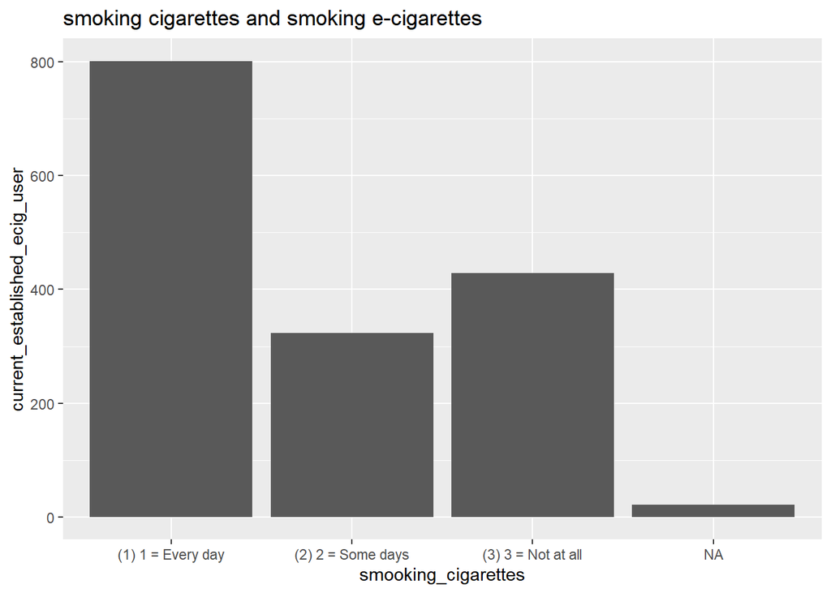

```r
## smoking cigarettes and smoking e-cigarettes
df1 %>%
  ggplot()+
  geom_col(aes(x = smooking_cigarettes, y = current_established_ecig_user))+
  labs(title = "smoking cigarettes and smoking e-cigarettes ")
```

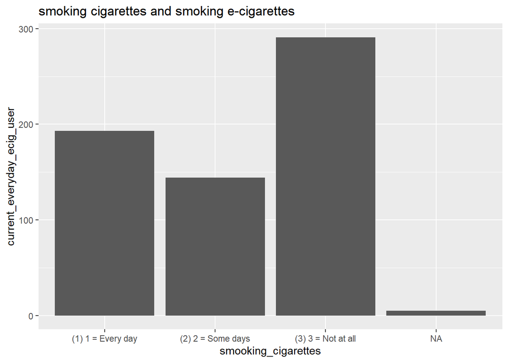

```r
df1 %>%
  ggplot()+
  geom_col(aes(x = smooking_cigarettes, y = current_everyday_ecig_user))+
  labs(title = "smoking cigarettes and smoking e-cigarettes ")
```

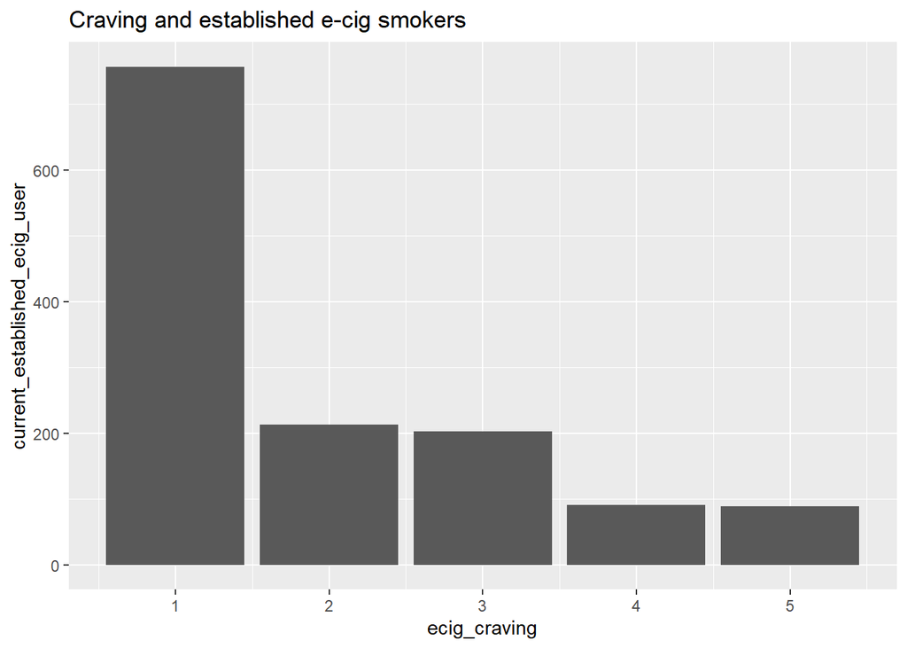

```r
#Craving and established e-cig smokers
df1 %>%
  ggplot()+
  geom_col(aes(x =ecig_craving , y= current_established_ecig_user))+
  labs(title = "Craving and established e-cig smokers")
```

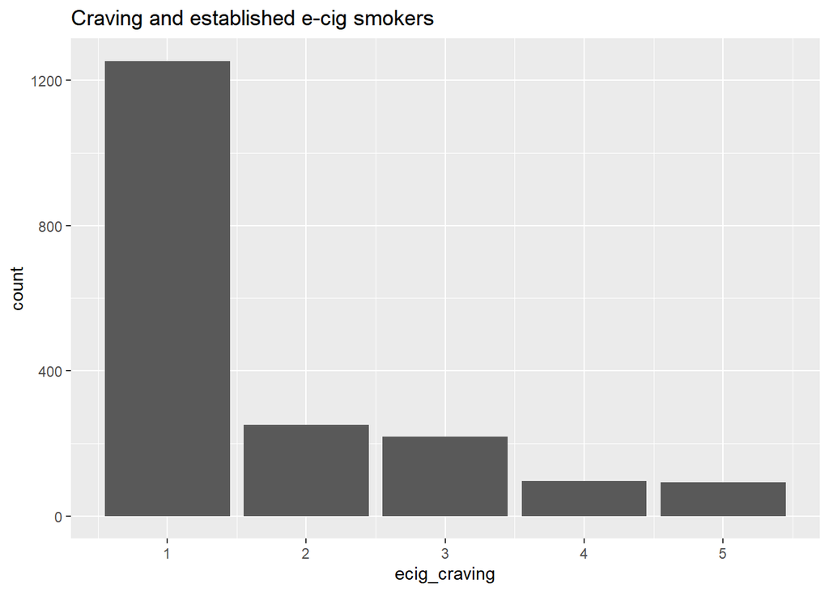

```r
df1 %>%
  ggplot()+
  geom_bar(aes(x = ecig_craving))+
  labs(title = "Craving and established e-cig smokers")
```

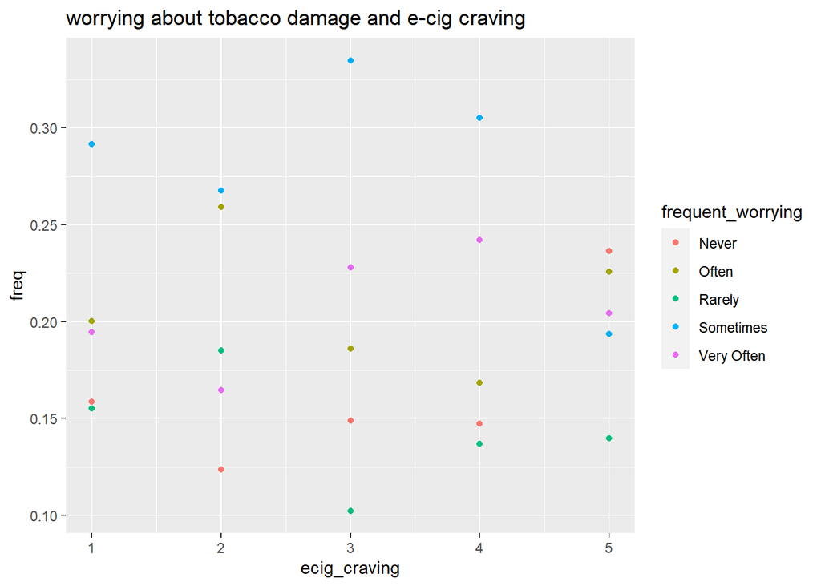

```r
## worrying about tobacco damage and e-cig craving
df_graph1 <- df1%>%
  select(R01_AX0004,ecig_craving)%>%
  mutate(frequent_worrying = case_when(R01_AX0004 == "(5) 5 = Very often" ~ "Very Often",
                                       R01_AX0004 == "(4) 4 = Often" ~ "Often",
                                       R01_AX0004 == "(3) 3 = Sometimes" ~ "Sometimes",
                                       R01_AX0004 == "(2) 2 = Rarely" ~ "Rarely",
                                       R01_AX0004 == "(1) 1 = Never" ~ "Never"
                                       ))%>%
  na.omit()%>%
  group_by(ecig_craving,frequent_worrying  )%>%
  summarise(n = n())%>%
  mutate(freq = n / sum(n))

df_graph1%>%
  ggplot(aes(x = ecig_craving, y = freq, color = frequent_worrying))+
  geom_point()+
  labs(title = "worrying about tobacco damage and e-cig craving" )
```

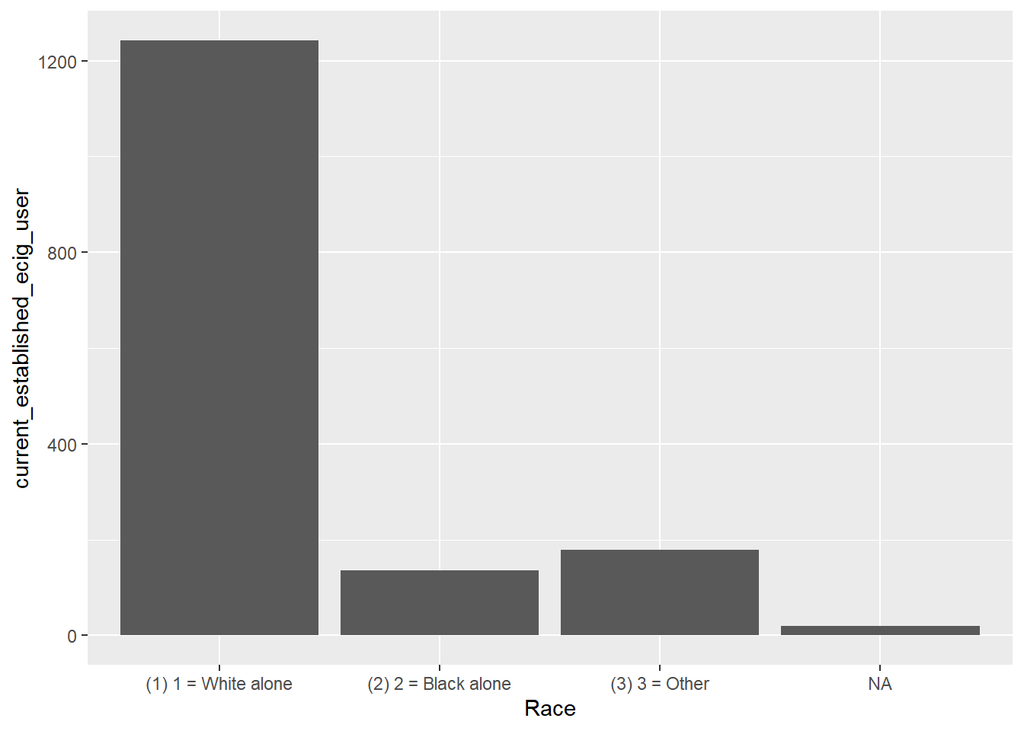

```r
########################################################################

### appendix graphs
df1 %>%
  ggplot()+
  geom_col(aes(x = Race, y = current_established_ecig_user))
```

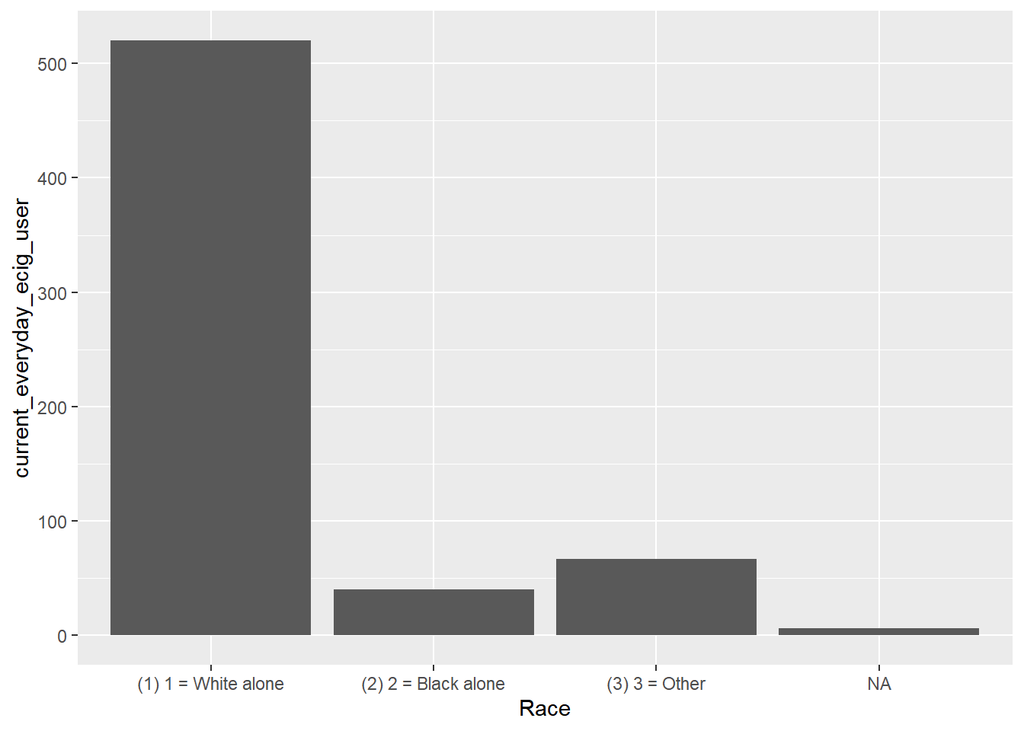

```r
df1 %>%
  ggplot()+
  geom_col(aes(x = Race, y = current_everyday_ecig_user))
```

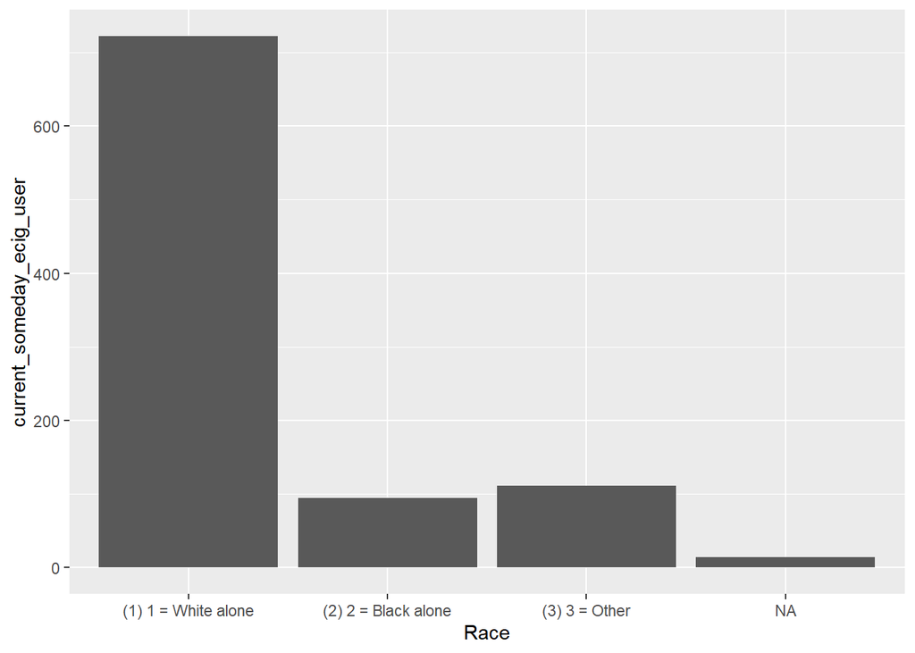

```r
df1 %>%
  ggplot()+
  geom_col(aes(x = Race, y = current_someday_ecig_user))
```

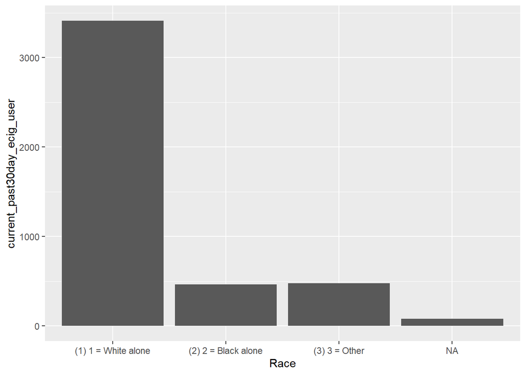

```r
df1 %>%
  ggplot()+
  geom_col(aes(x = Race, y = current_past30day_ecig_user))
```

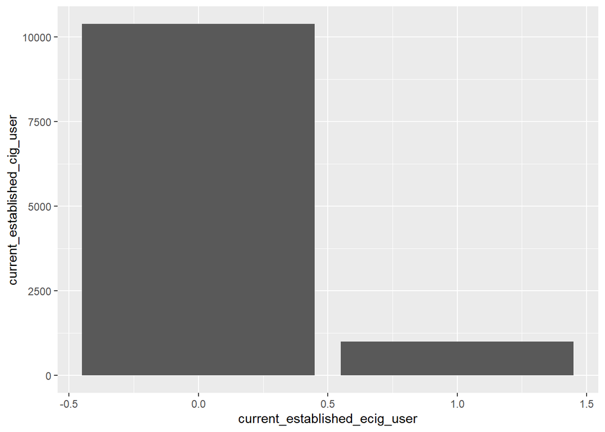

```r
df1 %>%
  ggplot()+
  geom_col(aes(x = current_established_ecig_user, y = current_established_cig_user))
```

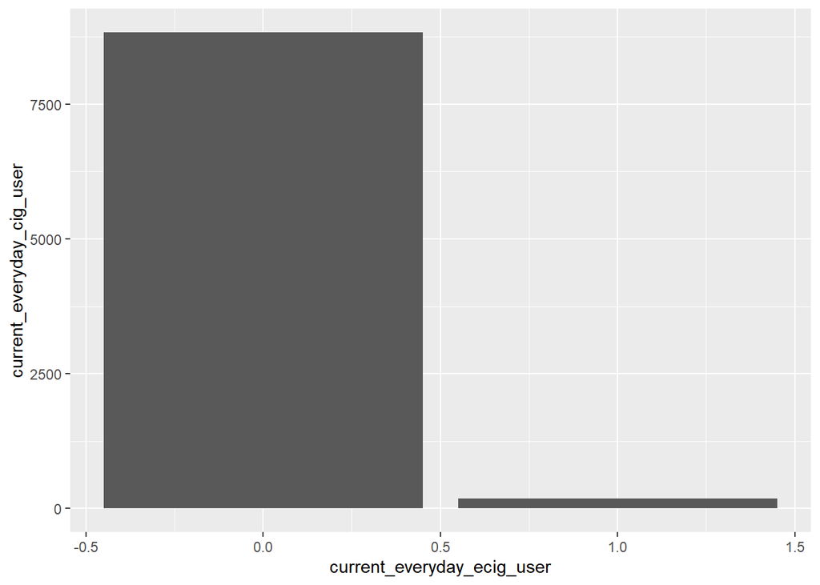

```r
df1 %>%
  ggplot()+
  geom_col(aes(x = current_everyday_ecig_user, y = current_everyday_cig_user))
```

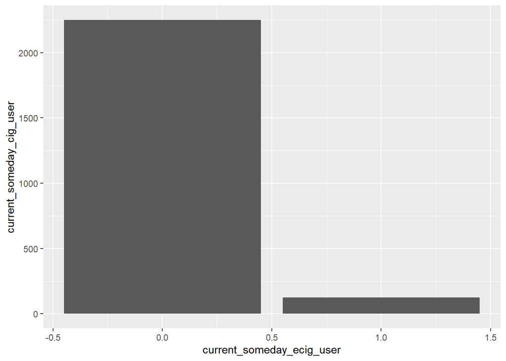

```r
df1 %>%
  ggplot()+
  geom_col(aes(x = current_someday_ecig_user, y = current_someday_cig_user))
```

### Decision tree

The decision tree is based on the 50 chosen variables with our subject of knowledge.

```r
library(vip)
library(patchwork)
library(tidyverse)
library(tidymodels)
library(rpart)
library(rpart.plot)
library(parsnip)
library(workflows)
theme_set(theme_minimal())

## We dropped the observations that didn't answer the question for outcome variable(ecig_craving).
df2<- chosen_variable_wave1%>%
  rename(ecig_craving = R01_AN0025E)%>%
  drop_na(ecig_craving)%>%
  rename(Race = R01R_A_RACECAT3) %>%
  rename(current_established_ecig_user = R01R_A_CUR_ESTD_ECIG) %>%
  rename(current_everyday_ecig_user = R01R_A_EDY_ECIG) %>%
  rename(current_someday_ecig_user = R01R_A_SDY_ECIG) %>%
  rename(current_past30day_ecig_user = R01R_A_P30D_ECIG)%>%
  rename(current_established_cig_user = R01R_A_CUR_ESTD_CIGS) %>%
  rename(current_everyday_cig_user = R01R_A_EDY_CIGS) %>%
  rename(current_someday_cig_user = R01R_A_SDY_CIGS) %>%
  rename(current_past30day_cig_user = R01R_A_P30D_CIGS)%>%
  rename(BMI = R01R_A_BMI )%>%
  rename(attitude = R01_AC9050)%>%
  rename(hhincome = R01R_A_AM0030)%>%
  rename(cig_crave = R01_AN0025)

df3<- wave1_adult%>%
  rename(ecig_craving = R01_AN0025E)%>%
  drop_na(ecig_craving)%>%
  rename(Race = R01R_A_RACECAT3) %>%
  rename(current_established_ecig_user = R01R_A_CUR_ESTD_ECIG) %>%
  rename(current_everyday_ecig_user = R01R_A_EDY_ECIG) %>%
  rename(current_someday_ecig_user = R01R_A_SDY_ECIG) %>%
  rename(current_past30day_ecig_user = R01R_A_P30D_ECIG)%>%
  rename(current_established_cig_user = R01R_A_CUR_ESTD_CIGS) %>%
  rename(current_everyday_cig_user = R01R_A_EDY_CIGS) %>%
  rename(current_someday_cig_user = R01R_A_SDY_CIGS) %>%
  rename(current_past30day_cig_user = R01R_A_P30D_CIGS)%>%
  rename(BMI = R01R_A_BMI )%>%
  rename(attitude = R01_AC9050)%>%
  rename(hhincome = R01R_A_AM0030)%>%
  rename(cig_crave = R01_AN0025)

set.seed(1234)

split <- initial_split(df2,
                       prop = 0.7,
                       strata = "ecig_craving")

train<- training(split)
test<- testing(split)



#creating a recipe for the supervised machine learning model
rec<-
  recipe(ecig_craving~  ., data = df2) %>%
  step_dummy(all_nominal_predictors())


bake(prep(rec, train), new_data = train)
```

```
## # A tibble: 1,337 x 119
##    R01_AE1022   BMI ecig_craving               R01_AC1002_X.2.~ R01_AC1003_X.2.~
##         <dbl> <dbl> <fct>                                 <dbl>            <dbl>
##  1         NA  29.2 (1) 1 = Not true of me at~                0                0
##  2         NA  26.6 (1) 1 = Not true of me at~                0                0
##  3          1  28.3 (1) 1 = Not true of me at~                0                1
##  4         NA  22.4 (1) 1 = Not true of me at~                0                0
##  5          1  19.6 (1) 1 = Not true of me at~                0                0
##  6          5  23.0 (1) 1 = Not true of me at~                0                0
##  7          1  27.9 (1) 1 = Not true of me at~                0                0
##  8         NA  17.9 (4) 4 = 4 on a scale of 1~                0                1
##  9          1  35.7 (1) 1 = Not true of me at~                0                0
## 10         10  NA   (1) 1 = Not true of me at~                0                0
## # ... with 1,327 more rows, and 114 more variables:
## #   R01_AC1003_X.3..3...Not.at.all <dbl>, R01_AC1004_X.2..2...No <dbl>,
## #   attitude_X.2..2...Slightly.harmful <dbl>,
## #   attitude_X.3..3...Somewhat.harmful <dbl>,
## #   attitude_X.4..4...Very.harmful <dbl>,
## #   attitude_X.5..5...Extremely.harmful <dbl>, R01_AE1001_X.2..2...No <dbl>,
## #   R01_AE1002_X.2..2...No <dbl>, R01_AE1003_X.2..2...Some.days <dbl>, ...
```

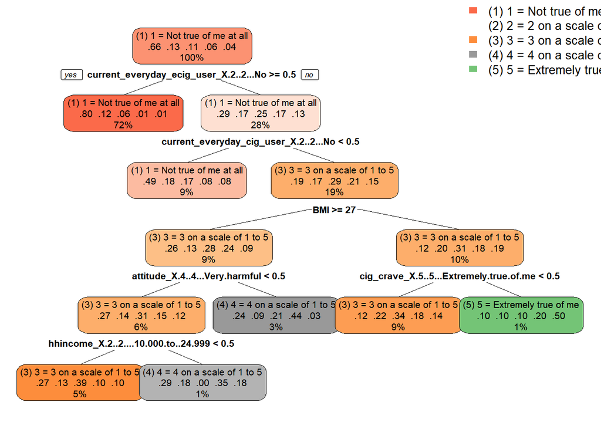

```r
cart_mod <-decision_tree()  %>%
  set_engine(engine = "rpart") %>%
  set_mode(mode = "classification")

cart_wf <- workflow() %>%
  add_model(cart_mod)%>%
  add_recipe(rec)

cart_fit <- cart_wf %>%
  parsnip::fit( data = train)

y_predict <-predict(cart_fit, new_data = test)


rpart.plot(x = cart_fit$fit$fit$fit,fallen.leaves=FALSE, tweak=1.2)
```

### data imputation for missing values

We found many observations have missing values for prediction variables. We used the KNN machine learning method to impute the missing values.

```r
library(tidymodels)
library(VIM)

df2_imp_f<- kNN(df2, k=5)
df2_imp_fct <- df2_imp_f%>%
  select(R01_AC1002: R01R_A_AGECAT7_IMP)


## converting to numeric
df3[sapply(df3, is.factor)] <- lapply(df3[sapply(df3, is.factor)], as.numeric)
df2[sapply(df2, is.factor)] <- lapply(df2[sapply(df2, is.factor)], as.numeric)

df2_imputed<- kNN(df2, k=5)

df2_imp<- df2_imputed %>%
  select(R01_AC1002: R01R_A_AGECAT7_IMP)
```

### Feature selection

Three methods were used to select variables based on their importance. Before that, we conducted feature selection on original data frame to prove our knowledge of subject.Except for variables that are similar to e-cig craving score(we dropped them because they are not conducive for predicting ecig-craving), we found our chosen variables matches with feature selection. Then, we did feature selection on our imputed data frame.Three methods were used: random forest, machine learning algorithm, and boruta(another random forest method).After that, we targeted around 30 variables.

```r
library(Boruta) #a feature ranking and selection algorithm based on random forests algorithm
library(caret)
library(party)


df3<- df3%>%
  select(-c(PERSONID,CASEID)) %>%
  mutate_all(~replace(., is.na(.), 0))

df2<- df2 %>%
  mutate_all(~replace(., is.na(.), 0))


#1. Random Forest Method
cf1 <- cforest(ecig_craving ~ . , data= df2, control=cforest_unbiased(mtry=2,ntree=50))
varimp(cf1)# get variable importance, based on mean decrease in accuracy
```

```
##                    R01_AC1002                    R01_AC1003
##                  8.188013e-06                  2.787079e-02
##                    R01_AC1004                      attitude
##                  1.383961e-02                  8.389300e-04
##                    R01_AE1001                    R01_AE1002
##                  0.000000e+00                  0.000000e+00
##                    R01_AE1003                    R01_AE1004
##                  9.887605e-02                  1.711274e-02
##                    R01_AE1022                    R01_AE1008
##                  2.297905e-02                  6.223883e-04
##                    R01_AE1090                    R01_AE1099
##                  1.172569e-02                  1.157789e-03
##                    R01_AE1100           R01R_A_RACECAT3_IMP
##                  7.992843e-03                  1.758154e-04
##                           BMI             R01R_A_SEXORIENT2
##                 -1.748987e-03                  4.763773e-04
##                 R01R_A_AC1006                 R01R_A_AE1006
##                  1.056554e-04                  2.736948e-03
##                 R01R_A_AE1007                 R01R_A_AE1020
##                  1.366759e-02                  7.910222e-02
##                 R01R_A_AM0018                      hhincome
##                  5.266277e-04                 -1.100344e-03
##                    R01_AN0015                     cig_crave
##                  7.024918e-03                  1.012602e-02
##                    R01_AN0215                   R01_AN0215E
##                  4.293402e-03                  4.284991e-03
##                    R01_AN0250                    R01_AR0110
##                  1.218776e-03                  2.022661e-03
##                    R01_AR0142                    R01_AX0005
##                  2.596318e-03                  3.291046e-03
##                    R01_AX0090                    R01_AX0091
##                  2.899475e-03                  4.142381e-03
##                    R01_AX0004                 R01_AX0064_01
##                 -2.384860e-03                 -1.263472e-03
##                 R01_AX0064_02                 R01_AX0064_03
##                  2.468398e-03                  6.703221e-04
##                    R01_AX0065                    R01_AR0144
##                 -4.492815e-04                 -2.718930e-04
##                    R01_AX0104                    R01_AX0105
##                  9.435594e-04                  5.231664e-04
##                          Race  current_established_cig_user
##                  2.423463e-03                  1.011071e-02
##     current_everyday_cig_user      current_someday_cig_user
##                  4.094817e-02                  4.701151e-03
##    current_past30day_cig_user current_established_ecig_user
##                  6.394328e-03                  4.222072e-02
##    current_everyday_ecig_user     current_someday_ecig_user
##                  1.815179e-01                  2.758487e-02
##   current_past30day_ecig_user            R01R_A_AGECAT7_IMP
##                  3.498236e-02                  2.303652e-03
```

```r
#on larger dataframe
#cf2 <- cforest(ecig_craving ~ . , data= df3, control=cforest_unbiased(mtry=2,ntree=50))
#varimp(cf2)# get variable importance, based on mean decrease in accuracy

#on imputed dataframe

cf3 <- cforest(ecig_craving ~ . , data= df2_imp, control=cforest_unbiased(mtry=2,ntree=50))
varimp(cf3)# get variable importance, based on mean decrease in accuracy
```

```
##                    R01_AC1002                    R01_AC1003
##                 -1.288553e-05                  3.948849e-02
##                    R01_AC1004                      attitude
##                  3.258261e-03                  2.382799e-03
##                    R01_AE1001                    R01_AE1002
##                  0.000000e+00                  0.000000e+00
##                    R01_AE1003                    R01_AE1004
##                  1.252714e-01                  4.316637e-03
##                    R01_AE1022                    R01_AE1008
##                  2.368825e-02                  1.307603e-03
##                    R01_AE1090                    R01_AE1099
##                  2.361225e-02                  5.413207e-03
##                    R01_AE1100           R01R_A_RACECAT3_IMP
##                  1.263212e-02                 -7.310389e-04
##                           BMI             R01R_A_SEXORIENT2
##                 -7.705589e-04                  1.880092e-03
##                 R01R_A_AC1006                 R01R_A_AE1006
##                 -1.372014e-04                  5.915716e-03
##                 R01R_A_AE1007                 R01R_A_AE1020
##                  1.008460e-02                  1.465640e-03
##                 R01R_A_AM0018                      hhincome
##                  1.706011e-03                 -1.535244e-03
##                    R01_AN0015                     cig_crave
##                  1.786501e-03                  1.528954e-03
##                    R01_AN0215                   R01_AN0215E
##                  2.918605e-03                  5.089665e-03
##                    R01_AN0250                    R01_AR0110
##                  3.326221e-03                  5.454144e-03
##                    R01_AR0142                    R01_AX0005
##                  2.017811e-04                  6.147223e-03
##                    R01_AX0090                    R01_AX0091
##                  1.968214e-03                  3.654089e-03
##                    R01_AX0004                 R01_AX0064_01
##                  1.452709e-03                  4.549266e-04
##                 R01_AX0064_02                 R01_AX0064_03
##                 -6.198652e-04                 -1.121605e-03
##                    R01_AX0065                    R01_AR0144
##                  1.214492e-03                 -1.483375e-03
##                    R01_AX0104                    R01_AX0105
##                  3.513803e-03                  1.717106e-03
##                          Race  current_established_cig_user
##                  1.086580e-03                  1.019683e-02
##     current_everyday_cig_user      current_someday_cig_user
##                  3.083674e-02                  5.782694e-03
##    current_past30day_cig_user current_established_ecig_user
##                  6.884625e-03                  6.175178e-02
##    current_everyday_ecig_user     current_someday_ecig_user
##                  1.039582e-01                  5.027546e-02
##   current_past30day_ecig_user            R01R_A_AGECAT7_IMP
##                  4.041725e-02                  1.757728e-03
```

```r
#2. Variable Importance from Machine Learning Algorithms
set.seed(11)
rPartMod <- train(ecig_craving ~ ., df2, method="rpart")
rpartImp <- varImp(rPartMod)
print(rpartImp)
```

```
## rpart variable importance
##
##   only 20 most important variables shown (out of 50)
##
##                               Overall
## R01R_A_AE1020                 100.000
## current_everyday_ecig_user    100.000
## R01_AE1003                     98.842
## current_established_ecig_user  30.698
## current_past30day_ecig_user    26.146
## current_everyday_cig_user      22.349
## R01_AC1003                     20.205
## current_established_cig_user    8.642
## R01_AX0005                      7.580
## R01_AC1004                      7.471
## Race                            0.000
## R01_AE1099                      0.000
## R01_AE1001                      0.000
## R01_AX0004                      0.000
## R01R_A_AM0018                   0.000
## R01R_A_AC1006                   0.000
## R01_AX0090                      0.000
## R01_AE1100                      0.000
## R01R_A_AE1007                   0.000
## R01_AX0091                      0.000
```

```r
set.seed(111)
rPartMod2 <- train(ecig_craving ~ ., df3, method="rpart")
rpartImp2 <- varImp(rPartMod2)
print(rpartImp2)
```

```
## rpart variable importance
##
##   only 20 most important variables shown (out of 1739)
##
##                        Overall
## R01_AN0055E             100.00
## R01_AN0090E              82.67
## R01_AN0015E              56.46
## R01_AN0085E              51.62
## R01_AN0010E              51.56
## R01_AN0050E              36.37
## R01_AN0060E              31.09
## R01_AN0095E              23.62
## R01_AS1060SU_RANDOM_01    0.00
## R01_AX0307C_09            0.00
## R01_A_PWGT60              0.00
## R01_AN0328                0.00
## R01_A_PWGT22              0.00
## R01_AH1005                0.00
## R01_AC9007_01             0.00
## R01_AG1025CG              0.00
## R01R_A_P30D_SMKLS         0.00
## R01_AG1021TC              0.00
## R01_AN0180                0.00
## R01_AX0083_03             0.00
```

```r
#deleting
#R01_AN0090E
#R01_AN0010E
#R01_AN0085E
#R01_AN0055E
#R01_AN0050E
#R01_AN0020E
#R01_AN0065E different ways of asking about e-cig craving


df3_d<- df3%>%
  select(-c(R01_AN0090E,
R01_AN0010E,
R01_AN0085E,
R01_AN0055E,
R01_AN0050E,
R01_AN0020E,
R01_AN0065E,
R01_AN0060E,
R01_AN0095E,
R01_AN0100E,
R01_AN0045E,
R01_AN0030E,
R01_AN0015E))

set.seed(222)
rPartMod3 <- train(ecig_craving ~ ., df3, method="rpart")
rpartImp3 <- varImp(rPartMod3)
print(rpartImp3)
```

```
## rpart variable importance
##
##   only 20 most important variables shown (out of 1739)
##
##                         Overall
## R01_AN0055E              100.00
## R01_AN0090E               82.67
## R01_AN0015E               56.46
## R01_AN0085E               51.62
## R01_AN0010E               51.56
## R01_AN0050E               36.37
## R01_AN0060E               31.09
## R01_AN0095E               23.62
## R01_AN0225E_01             0.00
## R01_AX0189                 0.00
## R01R_A_NVR_TOB             0.00
## R01_A_PWGT17               0.00
## R01_AX0002                 0.00
## R01_AX0105                 0.00
## R01_AX0156                 0.00
## R01_AS1003SM               0.00
## R01_AX0214                 0.00
## R01_AS1003SU               0.00
## R01_A_PWGT76               0.00
## R01R_A_DAYSBRAND_GFILTR    0.00
```

```r
## imputed dataframe
set.seed(333)
rPartMod4 <- train(ecig_craving ~ ., df2_imp, method="rpart")
rpartImp4 <- varImp(rPartMod4)
print(rpartImp4)
```

```
## rpart variable importance
##
##   only 20 most important variables shown (out of 50)
##
##                               Overall
## current_everyday_ecig_user    100.000
## R01_AE1003                     98.842
## R01_AE1022                     42.354
## current_established_ecig_user  30.698
## current_past30day_ecig_user    26.146
## current_everyday_cig_user      22.349
## R01_AC1003                     19.171
## current_established_cig_user    8.642
## R01_AX0005                      7.580
## R01_AE1100                      0.000
## R01_AE1004                      0.000
## R01R_A_AE1006                   0.000
## hhincome                        0.000
## R01_AX0091                      0.000
## R01R_A_SEXORIENT2               0.000
## current_someday_cig_user        0.000
## R01_AR0110                      0.000
## R01_AX0064_01                   0.000
## current_past30day_cig_user      0.000
## R01R_A_AGECAT7_IMP              0.000
```

```r
# 3.Boruta
set.seed(11)
boruta_output <- Boruta(ecig_craving ~ ., data=na.omit(df2), doTrace=2)
names(boruta_output)
```

```
##  [1] "finalDecision" "ImpHistory"    "pValue"        "maxRuns"
##  [5] "light"         "mcAdj"         "timeTaken"     "roughfixed"
##  [9] "call"          "impSource"
```

```r
boruta_signif <- getSelectedAttributes(boruta_output, withTentative = TRUE)
print(boruta_signif)
```

```
##  [1] "R01_AC1003"                    "R01_AC1004"
##  [3] "R01_AE1003"                    "R01_AE1004"
##  [5] "R01_AE1022"                    "R01_AE1090"
##  [7] "R01_AE1100"                    "R01R_A_AE1006"
##  [9] "R01R_A_AE1007"                 "R01R_A_AE1020"
## [11] "R01_AN0015"                    "cig_crave"
## [13] "R01_AN0215"                    "R01_AN0215E"
## [15] "R01_AR0110"                    "R01_AX0005"
## [17] "R01_AX0004"                    "R01_AX0104"
## [19] "current_established_cig_user"  "current_everyday_cig_user"
## [21] "current_someday_cig_user"      "current_past30day_cig_user"
## [23] "current_established_ecig_user" "current_everyday_ecig_user"
## [25] "current_someday_ecig_user"     "current_past30day_ecig_user"
## [27] "R01R_A_AGECAT7_IMP"
```

```r
set.seed(22)
boruta_output2 <- Boruta(ecig_craving ~ ., data=na.omit(df2_imp), doTrace=2)
boruta_signif2 <- getSelectedAttributes(boruta_output2, withTentative = TRUE)
print(boruta_signif2)
```

```
##  [1] "R01_AC1003"                    "attitude"
##  [3] "R01_AE1003"                    "R01_AE1004"
##  [5] "R01_AE1022"                    "R01_AE1090"
##  [7] "R01_AE1100"                    "R01R_A_AE1006"
##  [9] "R01R_A_AE1007"                 "R01R_A_AE1020"
## [11] "R01_AN0015"                    "cig_crave"
## [13] "R01_AN0215"                    "R01_AN0215E"
## [15] "R01_AR0110"                    "R01_AX0005"
## [17] "R01_AX0091"                    "R01_AX0004"
## [19] "R01_AR0144"                    "R01_AX0104"
## [21] "R01_AX0105"                    "current_established_cig_user"
## [23] "current_everyday_cig_user"     "current_someday_cig_user"
## [25] "current_past30day_cig_user"    "current_established_ecig_user"
## [27] "current_everyday_ecig_user"    "current_someday_ecig_user"
## [29] "current_past30day_ecig_user"   "R01R_A_AGECAT7_IMP"
```

```r
imps <- attStats(boruta_output2)
imps2 = imps[imps$decision != 'Rejected', c('meanImp', 'decision')]
head(imps2[order(-imps2$meanImp), ])  # descending sort
```

```
##                                meanImp  decision
## current_everyday_ecig_user    19.98650 Confirmed
## R01_AE1003                    19.52128 Confirmed
## R01_AE1022                    17.43659 Confirmed
## R01_AC1003                    13.92761 Confirmed
## current_everyday_cig_user     12.70416 Confirmed
## current_established_ecig_user 11.64019 Confirmed
```

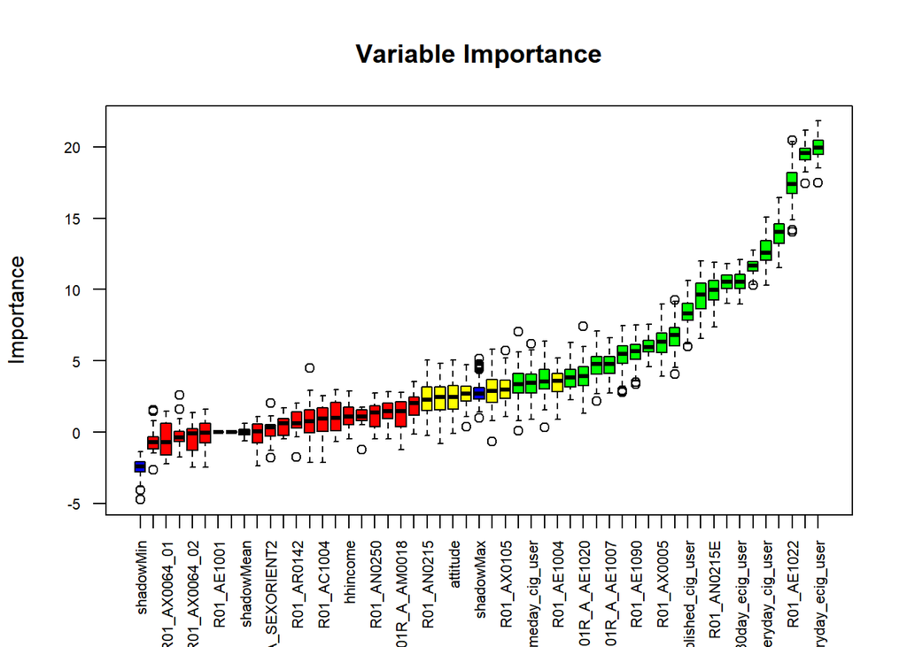

```r
plot(boruta_output2, cex.axis=.7, las=2, xlab="", main="Variable Importance")
```

### Supervised ML model with imputed data

We constructed supervised ML model with imputed data and used the models to predict e-cig craving. Two models were used random forest and lasso regression.We used the factor data frame for Random forest with classification mode. We also converted the factor df to numeric df for regression models(second random forest and lasso regression).

```r
library(vip)
library(patchwork)
library(tidyverse)
library(tidymodels)
library(rpart)
library(rpart.plot)
library(parsnip)
library(workflows)
library(ranger)
library(yardstick)

theme_set(theme_minimal())

df_dt<- df2_imp_fct %>%
  select(R01_AC1003,
  attitude,
  R01_AE1003,
  R01_AE1004,
  R01_AE1022,
  R01_AE1090,
  R01_AE1100,
  R01R_A_AE1006,
  R01R_A_AE1007,
  R01R_A_AE1020,
  R01_AN0015,
  cig_crave,
  R01_AN0215,
  R01_AN0215E,
  R01_AR0110,
  R01_AX0005,
  R01_AX0091,
  R01_AX0004,
  R01_AR0144,
  R01_AX0104,
  R01_AX0105,
  current_established_cig_user,
  current_everyday_cig_user,
  current_someday_cig_user,
  current_past30day_cig_user,
  current_established_ecig_user,
  current_everyday_ecig_user,
  current_someday_ecig_user,
  current_past30day_ecig_user,
  R01R_A_AGECAT7_IMP,
  hhincome,
  R01R_A_SEXORIENT2,
  R01_AX0064_01,
  ecig_craving)


df_dt2<- df2_imp %>%
  select(R01_AC1003,
  attitude,
  R01_AE1003,
  R01_AE1004,
  R01_AE1022,
  R01_AE1090,
  R01_AE1100,
  R01R_A_AE1006,
  R01R_A_AE1007,
  R01R_A_AE1020,
  R01_AN0015,
  cig_crave,
  R01_AN0215,
  R01_AN0215E,
  R01_AR0110,
  R01_AX0005,
  R01_AX0091,
  R01_AX0004,
  R01_AR0144,
  R01_AX0104,
  R01_AX0105,
  current_established_cig_user,
  current_everyday_cig_user,
  current_someday_cig_user,
  current_past30day_cig_user,
  current_established_ecig_user,
  current_everyday_ecig_user,
  current_someday_ecig_user,
  current_past30day_ecig_user,
  R01R_A_AGECAT7_IMP,
  hhincome,
  R01R_A_SEXORIENT2,
  R01_AX0064_01,
  ecig_craving)


set.seed(12345)
split2 <- initial_split(df_dt,
                       prop = 0.7,
                       strata = "ecig_craving")

train2<- training(split2)
test2<- testing(split2)



#creating a recipe for the supervised machine learning model



rec2<-
  recipe(ecig_craving~  ., data = df_dt) %>%
  step_dummy(all_nominal_predictors())


folds <- vfold_cv(data = train2, v = 10, repeats = 1)

bake(prep(rec2, train2), new_data = train2)
```

```
## # A tibble: 1,337 x 78
##    R01_AE1022 ecig_craving    R01_AC1003_X.2.~ R01_AC1003_X.3.~ attitude_X.2..2~
##         <dbl> <fct>                      <dbl>            <dbl>            <dbl>
##  1          3 (1) 1 = Not tr~                0                0                0
##  2          8 (1) 1 = Not tr~                0                0                0
##  3          1 (1) 1 = Not tr~                1                0                0
##  4         15 (1) 1 = Not tr~                0                0                0
##  5         24 (1) 1 = Not tr~                1                0                0
##  6          5 (1) 1 = Not tr~                0                1                0
##  7          5 (1) 1 = Not tr~                0                0                1
##  8          5 (1) 1 = Not tr~                0                0                0
##  9          1 (1) 1 = Not tr~                0                1                0
## 10          5 (1) 1 = Not tr~                0                0                0
## # ... with 1,327 more rows, and 73 more variables:
## #   attitude_X.3..3...Somewhat.harmful <dbl>,
## #   attitude_X.4..4...Very.harmful <dbl>,
## #   attitude_X.5..5...Extremely.harmful <dbl>,
## #   R01_AE1003_X.2..2...Some.days <dbl>, R01_AE1003_X.3..3...Not.at.all <dbl>,
## #   R01_AE1004_X.2..2...No <dbl>, R01_AE1090_X.2..2...No <dbl>,
## #   R01_AE1100_X.2..2...No <dbl>, ...
```

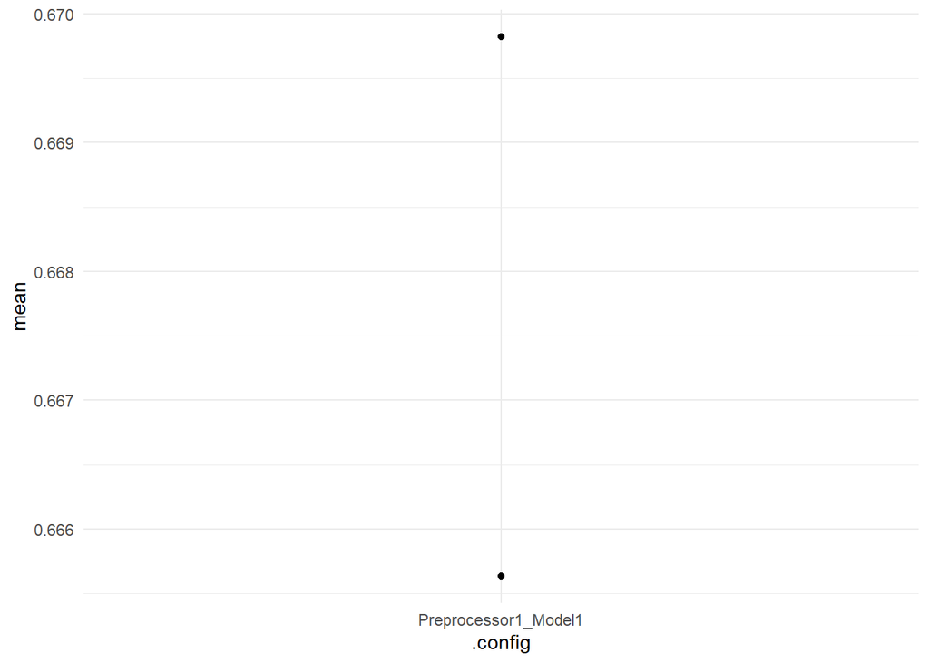

```r
# Random forest classification

rand_fore <-rand_forest(trees = 1000) %>%
  set_engine("ranger") %>%
  set_mode("classification")

rand_wf <- workflow() %>%
  add_recipe(rec2) %>%
  add_model(rand_fore)

rand_cv <- rand_wf %>%
 tune_grid(grid = 10,
            control = control_grid(save_pred = TRUE),
           resamples = folds)


rand_rmse<- rand_cv %>%
  collect_metrics(summarize = TRUE)

rand_rmse %>%
  ggplot(aes(x= .config, y= mean))+
  geom_point()
```

```r
rand_fit <- rand_wf%>%
  parsnip::fit(train2)

best_model_rmse <- bind_cols(
  test2,
  predict(object = rand_fit, new_data = test2)
)



yardstick::accuracy(data =best_model_rmse,
                    truth = ecig_craving,
                    estimate = .pred_class)
```

```
## # A tibble: 1 x 3
##   .metric  .estimator .estimate
##   <chr>    <chr>          <dbl>
## 1 accuracy multiclass     0.675
```

```r
yardstick::precision(data = best_model_rmse,
         truth = ecig_craving,
         estimate = .pred_class)
```

```
## # A tibble: 1 x 3
##   .metric   .estimator .estimate
##   <chr>     <chr>          <dbl>
## 1 precision macro          0.376
```

```r
yardstick::sensitivity(data = best_model_rmse,
         truth = ecig_craving,
         estimate = .pred_class)
```

```
## # A tibble: 1 x 3
##   .metric     .estimator .estimate
##   <chr>       <chr>          <dbl>
## 1 sensitivity macro          0.277
```

```r
yardstick::recall(data = best_model_rmse,
         truth = ecig_craving,
         estimate = .pred_class)
```

```
## # A tibble: 1 x 3
##   .metric .estimator .estimate
##   <chr>   <chr>          <dbl>
## 1 recall  macro          0.277
```

```r
conf_mat(data = best_model_rmse,
         truth = ecig_craving,
         estimate = .pred_class)
```

```
##                                 Truth
## Prediction                       (1) 1 = Not true of me at all
##   (1) 1 = Not true of me at all                            368
##   (2) 2 = 2 on a scale of 1 to 5                             0
##   (3) 3 = 3 on a scale of 1 to 5                             9
##   (4) 4 = 4 on a scale of 1 to 5                             0
##   (5) 5 = Extremely true of me                               1
##                                 Truth
## Prediction                       (2) 2 = 2 on a scale of 1 to 5
##   (1) 1 = Not true of me at all                              72
##   (2) 2 = 2 on a scale of 1 to 5                              1
##   (3) 3 = 3 on a scale of 1 to 5                              6
##   (4) 4 = 4 on a scale of 1 to 5                              0
##   (5) 5 = Extremely true of me                                1
##                                 Truth
## Prediction                       (3) 3 = 3 on a scale of 1 to 5
##   (1) 1 = Not true of me at all                              48
##   (2) 2 = 2 on a scale of 1 to 5                              2
##   (3) 3 = 3 on a scale of 1 to 5                             15
##   (4) 4 = 4 on a scale of 1 to 5                              0
##   (5) 5 = Extremely true of me                                0
##                                 Truth
## Prediction                       (4) 4 = 4 on a scale of 1 to 5
##   (1) 1 = Not true of me at all                              19
##   (2) 2 = 2 on a scale of 1 to 5                              0
##   (3) 3 = 3 on a scale of 1 to 5                              8
##   (4) 4 = 4 on a scale of 1 to 5                              0
##   (5) 5 = Extremely true of me                                1
##                                 Truth
## Prediction                       (5) 5 = Extremely true of me
##   (1) 1 = Not true of me at all                            12
##   (2) 2 = 2 on a scale of 1 to 5                            1
##   (3) 3 = 3 on a scale of 1 to 5                            5
##   (4) 4 = 4 on a scale of 1 to 5                            2
##   (5) 5 = Extremely true of me                              4
```

```r
## converting to numeric

 best_model_rmse[sapply(best_model_rmse, is.factor)] <- lapply(best_model_rmse[sapply(best_model_rmse, is.factor)],as.numeric)

 rmse(data = best_model_rmse, truth = ecig_craving, estimate = .pred_class )
```

```
## # A tibble: 1 x 3
##   .metric .estimator .estimate
##   <chr>   <chr>          <dbl>
## 1 rmse    standard        1.13
```

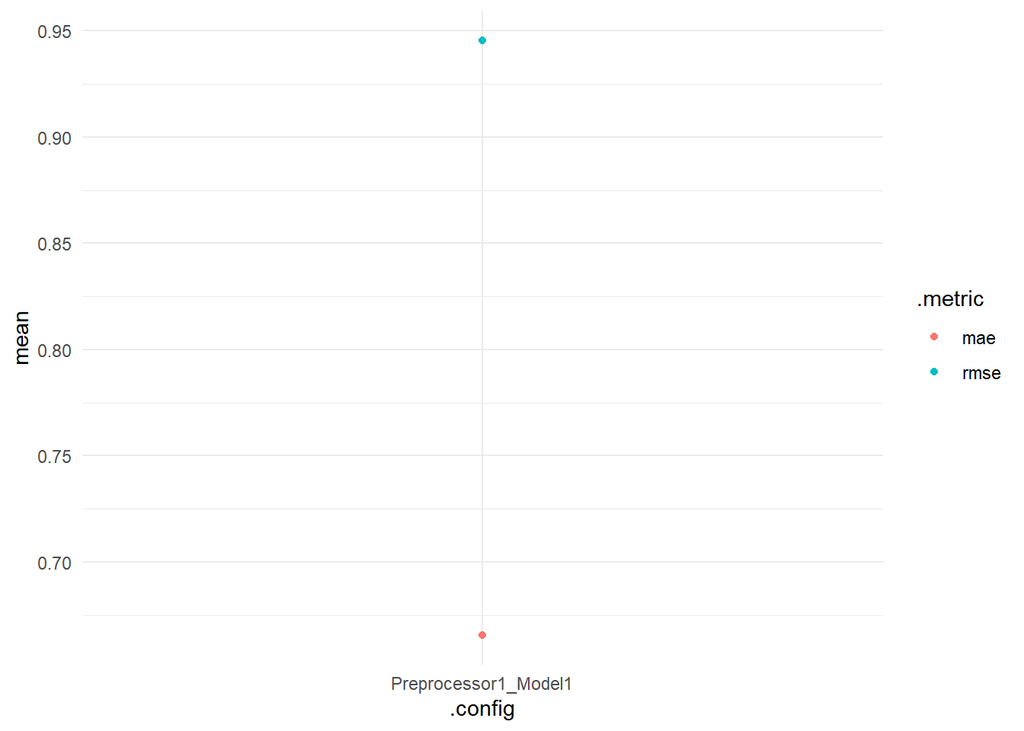

```r
## regression model

set.seed(123456)
split3 <- initial_split(df_dt2,
                       prop = 0.7,
                       strata = "ecig_craving")

train3<- training(split3)
test3<- testing(split3)


rec3<-
  recipe(ecig_craving~  ., data = df_dt2) %>%
  step_dummy(all_nominal_predictors())


folds2 <- vfold_cv(data = train3, v = 10, repeats = 1)

############### randome forest

rand_fore2 <-rand_forest(trees = 1000) %>%
  set_engine("ranger") %>%
  set_mode("regression")

rand_wf2 <- workflow() %>%
  add_recipe(rec3) %>%
  add_model(rand_fore2)

rand_cv2 <- rand_wf2 %>%
 tune_grid(grid = 10,
            control = control_grid(save_pred = TRUE),
           metrics = metric_set(mae, rmse),
           resamples = folds2)


rand_rmse2<- rand_cv2 %>%
  collect_metrics(summarize = TRUE)

rand_rmse2 %>%
   ggplot(aes(x= .config, y= mean, color = .metric))+
  geom_point()
```

```r
rand_fit2 <- rand_wf2%>%
  parsnip::fit(train3)

best_model_rmse2 <- bind_cols(
  test3,
  predict(object = rand_fit2, new_data = test3)
)


rmse(data = best_model_rmse2, truth = ecig_craving, estimate = .pred)
```

```
## # A tibble: 1 x 3
##   .metric .estimator .estimate
##   <chr>   <chr>          <dbl>
## 1 rmse    standard       0.886
```

```r
mae(data = best_model_rmse2, truth = ecig_craving, estimate = .pred)
```

```
## # A tibble: 1 x 3
##   .metric .estimator .estimate
##   <chr>   <chr>          <dbl>
## 1 mae     standard       0.634
```

```r
########### lasso
# lasso

lasso_grid <- grid_regular(penalty(), levels = 10)

lasso_mod <- linear_reg(
  penalty = tune(),
  mixture = 1
) %>%
  set_engine("glmnet")

lasso_wf <- workflow() %>%
  add_recipe(rec3) %>%
  add_model(lasso_mod)

lasso_cv <- lasso_wf %>%
  tune_grid(
    resamples = folds2,
    grid = lasso_grid,
    metrics = metric_set(mae, rmse)
  )

lasso_rmse<- lasso_cv %>%
  collect_metrics(summarize = TRUE)

lasso_cv %>%
  show_best(metric = "rmse", n = 1)
```

```
## # A tibble: 1 x 7
##   penalty .metric .estimator  mean     n std_err .config
##     <dbl> <chr>   <chr>      <dbl> <int>   <dbl> <chr>
## 1 0.00599 rmse    standard   0.943    10  0.0226 Preprocessor1_Model08
```

```r
lasso_best <- lasso_cv %>%
  select_best(metric = "rmse")

lasso_final <- finalize_workflow(
  lasso_wf,
  parameters = lasso_best
)

lasso_fit<- lasso_final%>%
  parsnip::fit(data = train3)

lasso_coefs <- lasso_final %>%
  parsnip::fit(data = train3) %>%
  extract_fit_parsnip() %>%
  vi(lambda = lasso_best$penalty)

print(lasso_coefs) #this tells us the coefficients of each variable and their magnitude
```

```
## # A tibble: 33 x 3
##    Variable                      Importance Sign
##    <chr>                              <dbl> <chr>
##  1 current_everyday_ecig_user        1.07   NEG
##  2 R01_AN0215E                       0.829  NEG
##  3 current_everyday_cig_user         0.205  POS
##  4 R01_AX0064_01                     0.205  NEG
##  5 current_established_ecig_user     0.195  NEG
##  6 current_established_cig_user      0.128  POS
##  7 cig_crave                         0.0970 POS
##  8 R01_AX0104                        0.0831 POS
##  9 R01_AE1004                        0.0798 NEG
## 10 R01_AC1003                        0.0726 POS
## # ... with 23 more rows
```

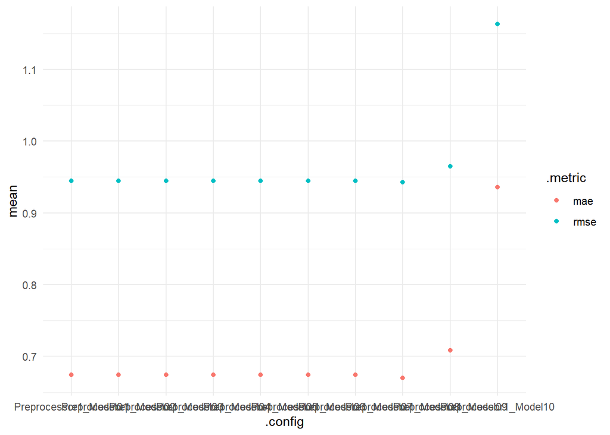

```r
lasso_rmse %>%
  ggplot(aes(x= .config, y= mean, color = .metric))+
  geom_point()
```

```r
best_model_rmse3 <- bind_cols(
  test3,
  predict(object = lasso_fit, new_data = test3)
)

rmse(data = best_model_rmse3, truth = ecig_craving, estimate = .pred)
```

```
## # A tibble: 1 x 3
##   .metric .estimator .estimate
##   <chr>   <chr>          <dbl>
## 1 rmse    standard       0.874
```

```r
mae(data = best_model_rmse3, truth = ecig_craving, estimate = .pred)
```

```
## # A tibble: 1 x 3
##   .metric .estimator .estimate
##   <chr>   <chr>          <dbl>
## 1 mae     standard       0.626
```

lasso and random forest model have similar rmse about 0.87 and 0.88.

### Extension- cluster analysis

clusters among the people who crave e-cig.

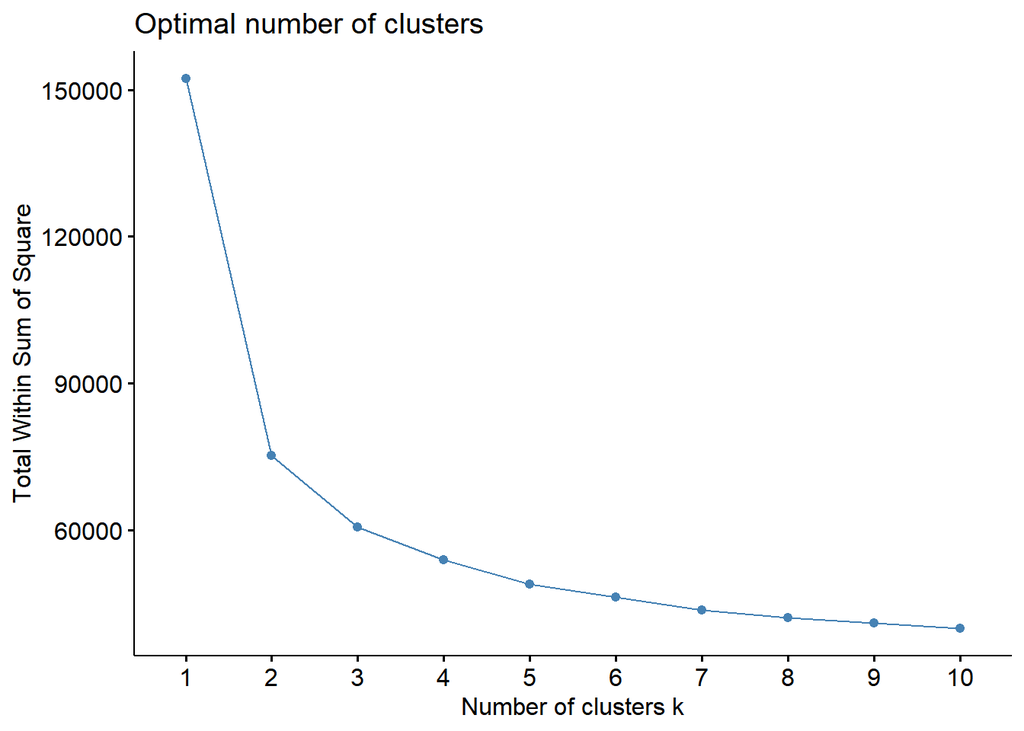

```r
library(factoextra)
library(patchwork)







set.seed(20220412)

# total within sum of squares
fviz_nbclust(df_dt2, FUN = kmeans, method = "wss")
```

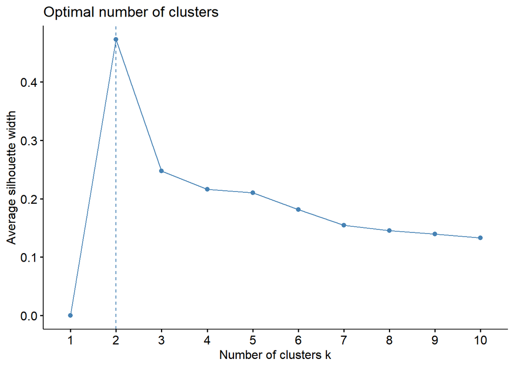

```r
# total silhouette width
fviz_nbclust(df_dt2, FUN = kmeans, method = "silhouette")
```

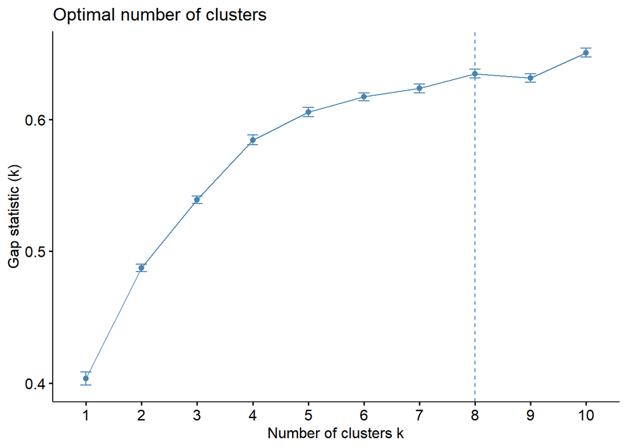

```r
# gap statistic
fviz_nbclust(df_dt2, FUN = kmeans, method = "gap_stat")
```

```r
## 2 or 8 clusters

#### creating PCA
pca<- prcomp(df_dt2)
summary(pca)
```

```
## Importance of components:
##                           PC1     PC2     PC3     PC4     PC5     PC6     PC7
## Standard deviation     7.4289 2.81114 1.81769 1.50949 1.28753 1.21358 1.10981
## Proportion of Variance 0.6929 0.09922 0.04148 0.02861 0.02081 0.01849 0.01546
## Cumulative Proportion  0.6929 0.79211 0.83359 0.86220 0.88301 0.90150 0.91697
##                            PC8    PC9   PC10    PC11    PC12    PC13    PC14
## Standard deviation     0.99735 0.8606 0.8131 0.77991 0.71442 0.68480 0.64627
## Proportion of Variance 0.01249 0.0093 0.0083 0.00764 0.00641 0.00589 0.00524
## Cumulative Proportion  0.92946 0.9387 0.9471 0.95469 0.96110 0.96699 0.97223
##                           PC15    PC16    PC17    PC18    PC19    PC20    PC21
## Standard deviation     0.58017 0.51672 0.49747 0.45148 0.43211 0.40795 0.35085
## Proportion of Variance 0.00423 0.00335 0.00311 0.00256 0.00234 0.00209 0.00155
## Cumulative Proportion  0.97646 0.97981 0.98292 0.98548 0.98782 0.98991 0.99146
##                           PC22    PC23    PC24   PC25    PC26    PC27    PC28
## Standard deviation     0.34067 0.31881 0.30789 0.2961 0.27930 0.25365 0.22020
## Proportion of Variance 0.00146 0.00128 0.00119 0.0011 0.00098 0.00081 0.00061
## Cumulative Proportion  0.99291 0.99419 0.99538 0.9965 0.99746 0.99827 0.99888
##                           PC29    PC30    PC31    PC32      PC33      PC34
## Standard deviation     0.21607 0.16403 0.12352 0.02706 7.956e-15 1.265e-15
## Proportion of Variance 0.00059 0.00034 0.00019 0.00001 0.000e+00 0.000e+00
## Cumulative Proportion  0.99946 0.99980 0.99999 1.00000 1.000e+00 1.000e+00
```

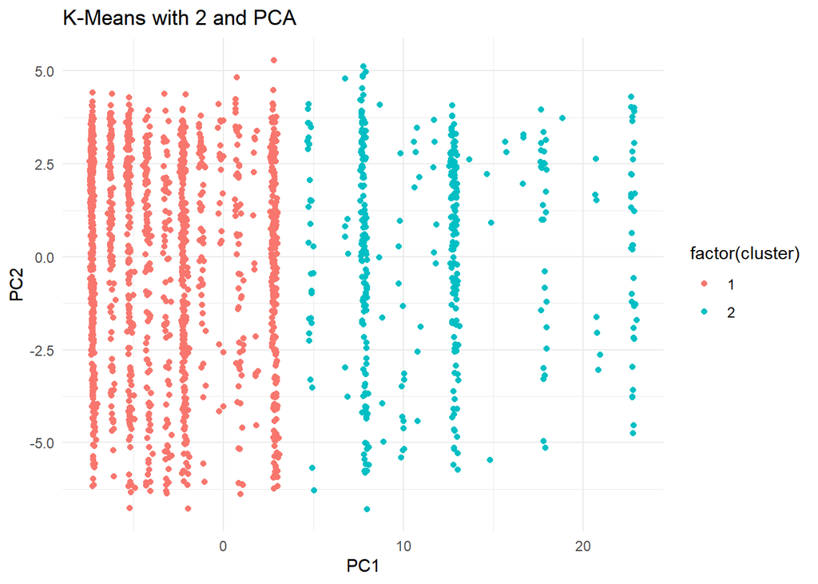

```r
pcs <- pca %>%
.$x %>%
  as_tibble()
######

pcs <-bind_cols(
  select(pcs, PC1, PC2),
  df_dt2)

  kmeans<- kmeans(
   df_dt2,
   centers = 2)

 cluster<- bind_cols(
    pcs,
    cluster = kmeans$cluster
  )

  ggplot() +
  geom_point(
    data = cluster,
     mapping = aes(x = PC1, y = PC2, color = factor(cluster))) +
    labs(
      title = "K-Means with 2 and PCA")
```

```r
# 8 clusters

pca<- prcomp(df_dt2)
summary(pca)
```

```
## Importance of components:
##                           PC1     PC2     PC3     PC4     PC5     PC6     PC7
## Standard deviation     7.4289 2.81114 1.81769 1.50949 1.28753 1.21358 1.10981
## Proportion of Variance 0.6929 0.09922 0.04148 0.02861 0.02081 0.01849 0.01546
## Cumulative Proportion  0.6929 0.79211 0.83359 0.86220 0.88301 0.90150 0.91697
##                            PC8    PC9   PC10    PC11    PC12    PC13    PC14
## Standard deviation     0.99735 0.8606 0.8131 0.77991 0.71442 0.68480 0.64627
## Proportion of Variance 0.01249 0.0093 0.0083 0.00764 0.00641 0.00589 0.00524
## Cumulative Proportion  0.92946 0.9387 0.9471 0.95469 0.96110 0.96699 0.97223
##                           PC15    PC16    PC17    PC18    PC19    PC20    PC21
## Standard deviation     0.58017 0.51672 0.49747 0.45148 0.43211 0.40795 0.35085
## Proportion of Variance 0.00423 0.00335 0.00311 0.00256 0.00234 0.00209 0.00155
## Cumulative Proportion  0.97646 0.97981 0.98292 0.98548 0.98782 0.98991 0.99146
##                           PC22    PC23    PC24   PC25    PC26    PC27    PC28
## Standard deviation     0.34067 0.31881 0.30789 0.2961 0.27930 0.25365 0.22020
## Proportion of Variance 0.00146 0.00128 0.00119 0.0011 0.00098 0.00081 0.00061
## Cumulative Proportion  0.99291 0.99419 0.99538 0.9965 0.99746 0.99827 0.99888
##                           PC29    PC30    PC31    PC32      PC33      PC34
## Standard deviation     0.21607 0.16403 0.12352 0.02706 7.956e-15 1.265e-15
## Proportion of Variance 0.00059 0.00034 0.00019 0.00001 0.000e+00 0.000e+00
## Cumulative Proportion  0.99946 0.99980 0.99999 1.00000 1.000e+00 1.000e+00
```

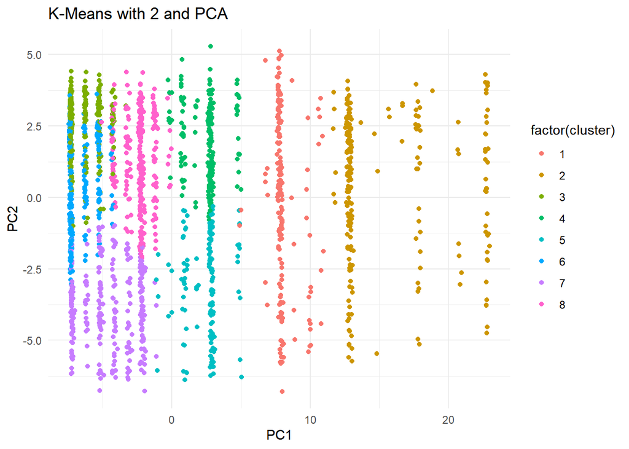

```r
pcs <- pca %>%
.$x %>%
  as_tibble()

pcs2 <-bind_cols(
  select(pcs, PC1, PC2, PC3, PC4, PC5, PC6, PC7, PC8),
  df_dt2)

  kmeans2<- kmeans(
   df_dt2,
   centers = 8)

 cluster2 <- bind_cols(
    pcs,
    cluster = kmeans2$cluster
  )

  ggplot() +
  geom_point(
    data = cluster2,
     mapping = aes(x = PC1, y = PC2, color = factor(cluster))) +
    labs(
      title = "K-Means with 2 and PCA")
```